# Nitrogen mass-balance budget

**Region:** pioneer_estuary  
**Description:** Pioneer River estuary, bounded by the Pioneer Mouth transect on the south (fluxflag region 2) and by upstream river boundaries to the north/west. River point sources are interior; tidal/oceanic exchange is via region 2.  
**Period:** 2021-04-01 to 2021-04-15 (14.0 days)  
**Generated:** 2026-05-31 22:11

## Period totals (tonnes N)

| Term | Cumulative (t N) | Interpretation |
| --- | --- | --- |
| **ΔStorage** (observed) | -1.10 | Change in total-N inventory between start and end of period |
| **B** — internal (denit + anammox) | +0.00 | Sum of net N losses to N<sub>2</sub> gas |
| **C** — atmospheric DIN deposition | +0.00 | Net N from atmospheric deposition into water |
| **D** — sediment-water flux | +0.00 | Net N from sediment efflux into water column |
| **E** — boundary inflow | -15.46 | Net N transported across the bounding transects (into CV) |
| **F** — point-source (rivers) | +39.76 | Riverine N input via interior source elements (vsource × msource) |
| **Closure residual** (should be ≈ 0) | **-25.40** | 2316.0% of ΔStorage |

Initial storage on first timestep: +1.88 t N. Conversion: 1 mmol N × 14.0067 / 1e9 = tonnes N.

## Time series — instantaneous

Stacked-area: each coloured layer is one budget term contributing to dM/dt. The black line shows the observed dM/dt computed from finite-differences of the storage time series. Where the line follows the top of the stacks, the budget closes.

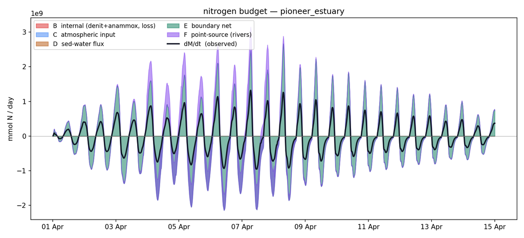

## Cumulative time-integrals

Each term integrated from `t0` in tonnes N. The black line is observed ΔStorage. Closure if the coloured lines sum to the black line.

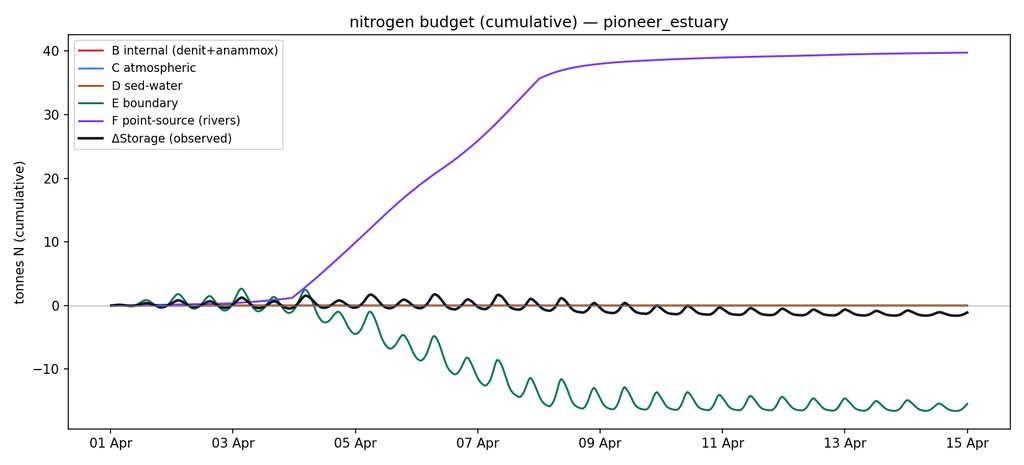

## How each term is computed

### Term A — Storage (mmol N)

Volume integral of all N-containing state-variable concentrations over the control volume's elements and layers:

```
M(t) = Σelem∈CV Σlayer
  c(elem, layer, t) × layer_ht × elem_area × n_per_mol
```

State pools summed (all in mmol N/m³ after the per-mol conversion): NIT_amm, NIT_nit, OGM_don, OGM_pon, PHY_mixed (×16/106 Redfield N:C).

### Term B — Internal rates (mmol N/day)

Volume integral of process rates that are net losses from the total-N pool:

- `NIT_denit` (NO<sub>3</sub> → N<sub>2</sub>, sign −1)
- `NIT_anammox` (NH<sub>4</sub>+NO<sub>2</sub> → N<sub>2</sub>, sign −1)

Other rates (nitrification, DNRA, mineralisation, hydrolysis, phyto uptake) are tracked individually but their `sign_in_pool = 0` so they cancel in the total-N closure.

### Term C — Atmospheric flux (mmol N/day)

Area integral of `NIT_din_atm` (2D sheet, mmol N/m²/day) over the surface area of the CV.

### Term D — Sediment-water flux (mmol N/day)

Sum of 2D sheet diagnostics, area-integrated over the CV:

- NIT_amm_dsf, NIT_nit_dsf, OGM_don_swi, OGM_pon_swi, PHY_phy_swi_n

All taken as *positive into the water column*.

### Term E — Boundary inflow (mmol N/day)

Tracer columns summed (with n-per-mol weighting): NIT_amm, NIT_nit, OGM_don, OGM_pon, PHY_mixed (×16/106).

### Term F — Point-source (river) input (mmol N/day)

River nutrient inputs from `source_sink.in` + `vsource.th` + `msource.th` for sources whose target element is interior to the control volume:

```
F(t) = Σsrc∈CV Σt∈N-pools
  Qsrc(t) × csrc,t(t) × n_per_mol[t] × 86400
```

msource.th concentrations are in mmol/m³ (same unit as flux.out), so no extra conversion is needed. Pools summed: NIT_amm, NIT_nit, OGM_don, OGM_pon, PHY_mixed (×16/106).

**Sources inside this CV (3):**

| src # | element ID (1-indexed) |
| --- | --- |
| 1 | 10627 |
| 2 | 56271 |
| 3 | 50526 |

## Closure-check interpretation

If closure residual is small relative to ΔStorage (say < 10%), the budget is closed within numerical accuracy. Common reasons for non-closure:

- **Time-cadence mismatch** between scribed and cmb outputs (storage is read on scribed cadence; rates+fluxes on cmb cadence).
- **flux.out tracer ordering** mismatched against `DEFAULT_TRACER_ORDER` in `boundary_fluxes.py`.
- **fluxflag.prop boundary signs** incorrectly specified (positive flux at a transect goes IN one direction; the sign in the region config must reflect whether that direction is into or out of the CV).
- **msource.th tracer-column ordering** — Term F assumes the AED state-var registration order in `DEFAULT_AED_TRACER_ORDER` (`point_sources.py`); override if your build differs.